# Lab 10b - Boosting

Shih-Ting (Cindy) Huang

03/24/2022

```r
knitr::opts_chunk$set(eval = T, include  = T, warning=F, message=F)
```

# Learning goals

- Perform gradient boosting and extreme gradient boosting on the `heart` data.
- Compare the performance of the two.

# Lab description

For this lab we will be working with the `heart` dataset that you can download from [here](https://github.com/JSC370/jsc370-2022/blob/main/data/heart/heart.csv)

### Setup packages

You should install and load `gbm` (gradient boosting) and `xgboost` (extreme gradient boosting).

```r
install.packages(c(,"gbm","xgboost","caret"))
```

## Question 1: Gradient Boosting

Evaluate the effect of critical boosting parameters (number of boosting iterations, shrinkage/learning rate, and tree depth/interaction). In `gbm` the number of iterations is controlled by `n.trees` (default is 100), the shrinkage/learning rate is controlled by `shrinkage` (default is 0.001), and interaction depth by `interaction.depth` (default is 1).

Note, boosting can overfit if the number of trees is too large. The shrinkage parameter controls the rate at which the boosting learns. Very small $\lambda$ can require using a very large number of trees to achieve good performance. Finally, interaction depth controls the interaction order of the boosted model. A value of 1 implies an additive model, a value of 2 implies a model with up to 2-way interactions, etc. the default is 1.

1. Split the heart data into training and testing. Also need to make character variables into numeric variables and get rid of missing values.

```r
set.seed(301)

# XGBoost isn't NA-friendly, so we omit them from the dataset
# Changing character variables to numeric
heart$AHD_num <- ifelse(heart$AHD=="Yes",1,0)
heart$ChestPain_num <- ifelse(heart$ChestPain=="asymptomatic",1,ifelse(heart$ChestPain=="nonanginal",2,ifelse(heart$ChestPain=="nontypical",3,0)))
heart$Thal_num <- ifelse(heart$Thal=="fixed",1,ifelse(heart$Thal=="normal",2,0))
heart <- heart %>% select(-c(AHD, ChestPain, Thal))
heart <-na.omit(heart)

# Lists of indices
train = sample(1:nrow(heart), floor(nrow(heart) * 0.7))
test = setdiff(1:nrow(heart), train)
```

2. Set the seed and train a boosting classification with `gbm` using 10-fold cross-validation (`cv.folds=10`) on the training data with `n.trees = 5000`, `shrinkage = 0.001`, and `interaction.depth =1`. Plot the cross-validation errors as a function of the boosting iteration and calculate the test MSE.

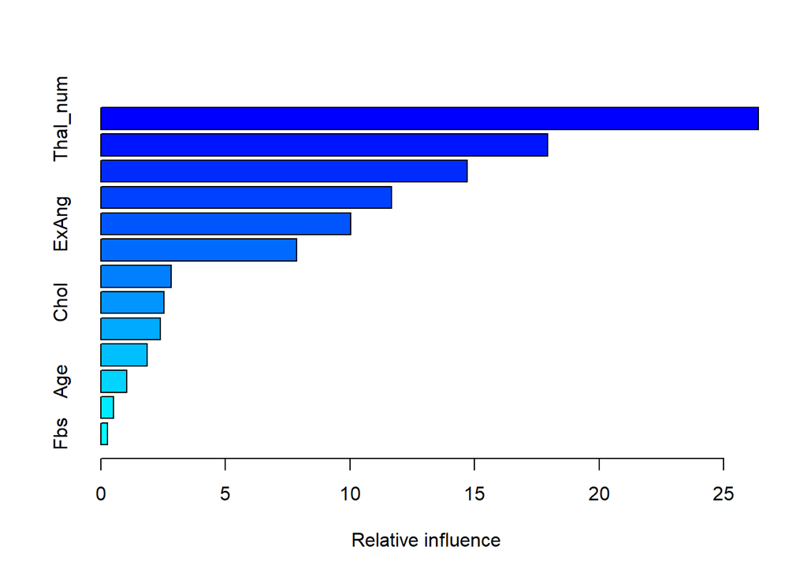

```
##                         var    rel.inf
## Thal_num           Thal_num 26.3939692
## ChestPain_num ChestPain_num 17.9274629
## Ca                       Ca 14.6993827
## MaxHR                 MaxHR 11.6704959
## ExAng                 ExAng 10.0376320
## Oldpeak             Oldpeak  7.8528744
## Sex                     Sex  2.8304236
## Chol                   Chol  2.5295325
## Slope                 Slope  2.3797678
## RestBP               RestBP  1.8512769
## Age                     Age  1.0494106
## RestECG             RestECG  0.5204809
## Fbs                     Fbs  0.2572904
```

```r
set.seed(123)

heart_boost = gbm(AHD_num~., data = heart[train,], distribution="bernoulli", n.trees=5000, shrinkage=0.001, interaction.depth=1, cv.folds=10, class.stratify.cv=T)

summary(heart_boost)
```

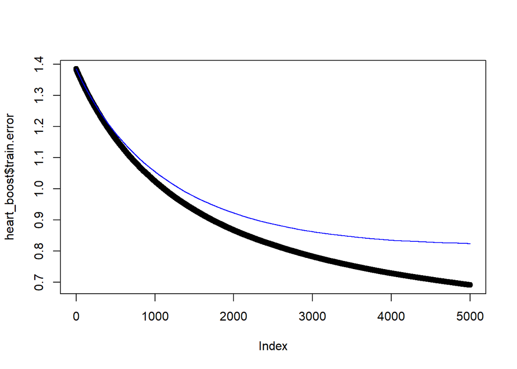

```r
# Train error for every iteration
plot(heart_boost$train.error)
lines(heart_boost$cv.error, col='blue')
```

```r
yhat_boost <- predict(heart_boost, newdata = heart[test,], n.trees=5000)

mean((yhat_boost-heart[test,"AHD_num"])^2)
```

```
## [1] 2.763688
```

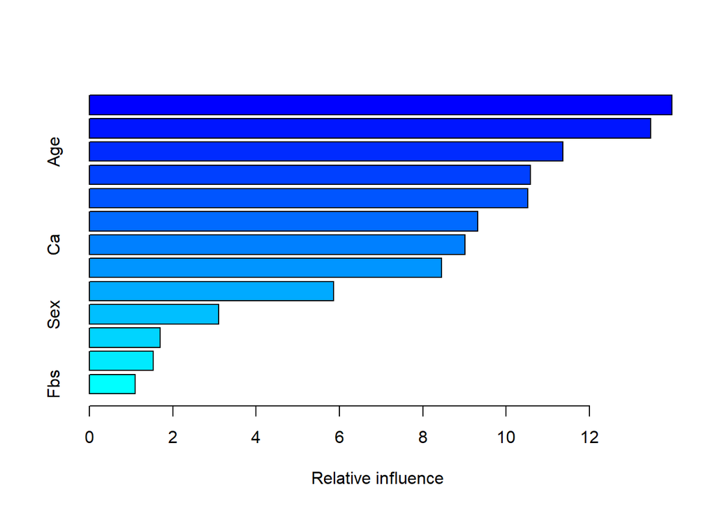

```
##                         var   rel.inf
## Thal_num           Thal_num 13.979319
## MaxHR                 MaxHR 13.465963
## Age                     Age 11.368393
## ChestPain_num ChestPain_num 10.579832
## Oldpeak             Oldpeak 10.517495
## Chol                   Chol  9.320428
## Ca                       Ca  9.018109
## RestBP               RestBP  8.453280
## ExAng                 ExAng  5.860980
## Sex                     Sex  3.103241
## Slope                 Slope  1.701520
## RestECG             RestECG  1.531917
## Fbs                     Fbs  1.099523
```

```r
set.seed(123)

heart_boost2 = gbm(AHD_num~., data = heart[train,], distribution="bernoulli", n.trees=5000, shrinkage=0.01, interaction.depth=2, cv.folds=10, class.stratify.cv=T)

summary(heart_boost2)
```

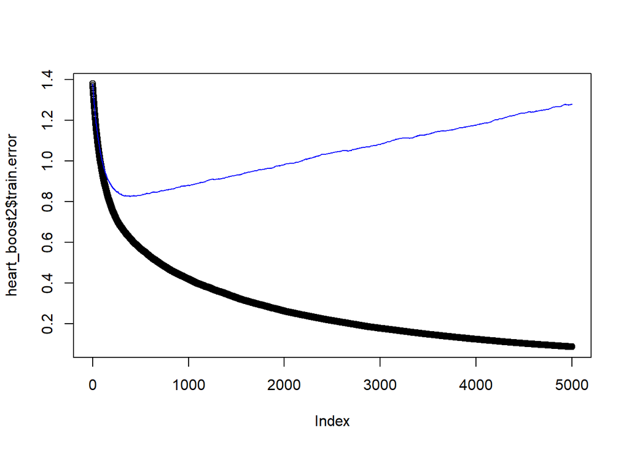

```r
# Train error for every iteration
plot(heart_boost2$train.error)
lines(heart_boost2$cv.error, col='blue')
```

```r
yhat2_boost <- predict(heart_boost2, newdata = heart[test,], n.trees=5000)

mean((yhat2_boost-heart[test,"AHD_num"])^2)
```

```
## [1] 22.2619
```

## Question 2: Extreme Gradient Boosting

Training an xgboost model with `xgboost` and perform a grid search for tuning the number of trees and the maxium depth of the tree. Also perform 10-fold cross-validation and determine the variable importance. Finally, compute the test MSE.